# Final Tutorial: Predicting Wine Quality

Liam O'Flynn

Wine quality is a multifaceted concept influenced by a combination of chemical, sensory, and subjective factors. It's often evaluated through sensory analysis and expert judgment, considering attributes such as taste, aroma, appearance, and overall balance. The chemical composition of wine plays a pivotal role in determining its quality, with key components including acidity, sugar levels, alcohol content, tannins, and volatile compounds. Balancing these components is crucial; for example, high acidity can provide freshness but might lead to a sour taste if excessive. Similarly, optimal alcohol content contributes to body and flavor, while excessive levels can result in a burning sensation.

Furthermore, wine quality is closely tied to regional variations, known as terroir, which encompasses factors like soil composition, climate, and grape variety. Different grape varieties and their specific growing conditions lead to distinct flavor profiles, making terroir a significant determinant of wine quality and uniqueness. Additionally, aging in various types of barrels or bottles can impart complexity and nuances to the wine, further influencing its overall quality and value.

While there are general quality standards, wine appreciation is ultimately subjective, varying based on personal preferences and cultural context. Hence, wine quality assessment often involves a blend of objective chemical analysis and the subjective experiences of tasters and consumers. This intricate interplay of objective attributes, sensory experiences, and individual preferences underscores the complexity and allure of wine quality assessment in both the scientific and social realms.

## Part 1: Data Collection

Our goal is to develop a model that can accurately predict a wine's quality rating based on the combination of these various attributes. Determining a predictive model for red wine quality using machine learning techniques holds broader significance for both consumers and producers in the wine industry. High-quality wine is not only a cultural and gastronomic treasure but also a thriving business. A reliable model that accurately predicts wine quality based on chemical attributes can empower producers to optimize their production processes, leading to enhanced consistency and quality control. On the consumer side, a predictive model can assist enthusiasts in making informed purchasing decisions, ensuring a delightful wine experience. Moreover, beyond the wine industry, this endeavor exemplifies the application of machine learning to enhance decision-making across diverse domains, underscoring the versatility and transformative potential of data-driven insights.

Building such a model will involve data preprocessing, feature engineering, model selection, and performance evaluation — all fundamental aspects of the data science pipeline. By delving into this project, data scientists can hone their skills in data wrangling, statistical analysis, and machine learning modeling, reinforcing their ability to tackle real-world challenges across industries

First we will set up our imports and some simple cleaning and parsing.

```python
import pandas as pd
import matplotlib.pyplot as plt
from sklearn.model_selection import train_test_split
from sklearn.linear_model import LogisticRegression
from sklearn.preprocessing import StandardScaler
from sklearn.metrics import ConfusionMatrixDisplay, confusion_matrix

wine = pd.read_csv("winequality-red.csv")
wine.tail()
```

|  | fixed acidity | volatile acidity | citric acid | residual sugar | chlorides | free sulfur dioxide | total sulfur dioxide | density | pH | sulphates | alcohol | quality |
| --- | --- | --- | --- | --- | --- | --- | --- | --- | --- | --- | --- | --- |
| 1594 | 6.2 | 0.600 | 0.08 | 2.0 | 0.090 | 32.0 | 44.0 | 0.99490 | 3.45 | 0.58 | 10.5 | 5 |
| 1595 | 5.9 | 0.550 | 0.10 | 2.2 | 0.062 | 39.0 | 51.0 | 0.99512 | 3.52 | 0.76 | 11.2 | 6 |
| 1596 | 6.3 | 0.510 | 0.13 | 2.3 | 0.076 | 29.0 | 40.0 | 0.99574 | 3.42 | 0.75 | 11.0 | 6 |
| 1597 | 5.9 | 0.645 | 0.12 | 2.0 | 0.075 | 32.0 | 44.0 | 0.99547 | 3.57 | 0.71 | 10.2 | 5 |
| 1598 | 6.0 | 0.310 | 0.47 | 3.6 | 0.067 | 18.0 | 42.0 | 0.99549 | 3.39 | 0.66 | 11.0 | 6 |

```python
wine.size
```

```
19188
```

Now we can clean our data a bit by removing duplicate rows:

```python
wine.drop_duplicates(
    subset=[
        "fixed acidity",
        "volatile acidity",
        "citric acid",
        "residual sugar",
        "chlorides",
        "free sulfur dioxide",
        "total sulfur dioxide",
        "density",
        "pH",
        "sulphates",
        "alcohol",
        "quality",
    ],
    keep="first",
    inplace=True,
)
wine.size
```

```
16308
```

Let's take a look at our columnns:

```python
wine.info()
```

```
<class 'pandas.core.frame.DataFrame'>
Index: 1359 entries, 0 to 1598
Data columns (total 12 columns):
 #   Column                Non-Null Count  Dtype
---  ------                --------------  -----
 0   fixed acidity         1359 non-null   float64
 1   volatile acidity      1359 non-null   float64
 2   citric acid           1359 non-null   float64
 3   residual sugar        1359 non-null   float64
 4   chlorides             1359 non-null   float64
 5   free sulfur dioxide   1359 non-null   float64
 6   total sulfur dioxide  1359 non-null   float64
 7   density               1359 non-null   float64
 8   pH                    1359 non-null   float64
 9   sulphates             1359 non-null   float64
 10  alcohol               1359 non-null   float64
 11  quality               1359 non-null   int64
dtypes: float64(11), int64(1)
memory usage: 138.0 KB
```

The updated dataset consists of 1359 entries, each corresponding to a distinct sample. The dataset comprises 12 columns, collectively contributing to a comprehensive description of the samples. These columns encompass a diverse range of numerical attributes. The numerical attributes encompass essential characteristics such as acidity levels (fixed acidity, volatile acidity, citric acid), residual sugar content, chlorides concentration, free and total sulfur dioxide content, density, pH value, sulphate concentration, alcohol content, and quality rating. These attributes are stored as floating-point numbers (float64) or integers (int64), with all columns containing complete data without any missing values. This dataset now appears to be well-structured and suitable for our analyses, visualization, and modeling tasks, given the variety of attributes that capture different aspects of the samples' properties.

## Part 2: Data Visualization

Next we will do some preliminary visual analysis of our cleaned dataset. We hope to determine some information about the distribution of samples themselves and make a few early predictions as to how certain features will correlate with perceived wine quality.

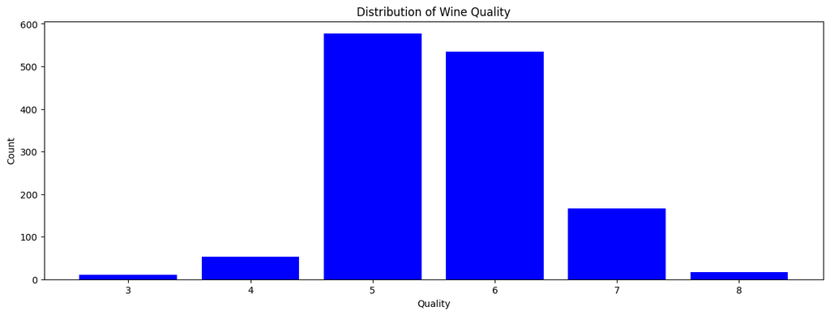

```python
plt.figure(figsize=(15, 5))

# Count the occurrences of each unique value in the 'quality' column
quality_counts = wine["quality"].value_counts()

# Extract the unique quality values and their corresponding counts
quality_values = quality_counts.index
quality_counts = quality_counts.values

# Create a bar plot
plt.bar(quality_values, quality_counts, color="blue")

# Set plot title and labels
plt.title("Distribution of Wine Quality")
plt.xlabel("Quality")
plt.ylabel("Count")

# Show the plot
plt.show()
```

Now, let's analyze how various attributes influence wine quality.

```python
wine.corr
```

```
<bound method DataFrame.corr of       fixed acidity  volatile acidity  citric acid  residual sugar  chlorides  \
0               7.4             0.700         0.00             1.9      0.076
1               7.8             0.880         0.00             2.6      0.098
2               7.8             0.760         0.04             2.3      0.092
3              11.2             0.280         0.56             1.9      0.075
5               7.4             0.660         0.00             1.8      0.075
...             ...               ...          ...             ...        ...
1593            6.8             0.620         0.08             1.9      0.068
1594            6.2             0.600         0.08             2.0      0.090
1595            5.9             0.550         0.10             2.2      0.062
1597            5.9             0.645         0.12             2.0      0.075
1598            6.0             0.310         0.47             3.6      0.067

      free sulfur dioxide  total sulfur dioxide  density    pH  sulphates  \
0                    11.0                  34.0  0.99780  3.51       0.56
```

[output cut: 25 more lines]

Let's plot quality vs some of these attributes to confirm these findings visually.

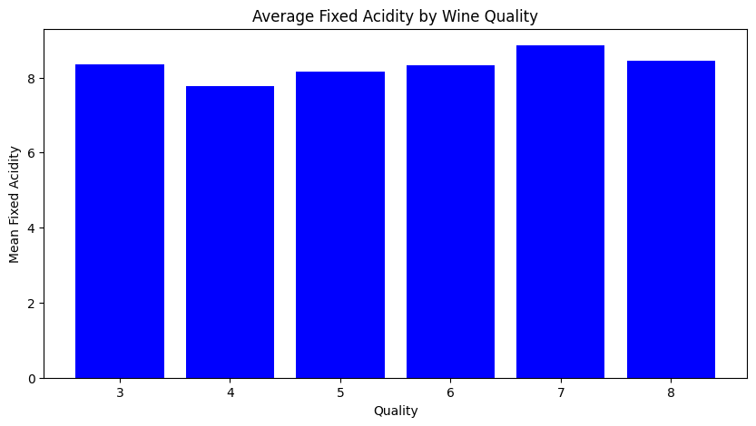

```python
fig = plt.figure(figsize=(10, 5))

# Grouping data by 'quality' and calculating the mean of 'fixed acidity' for each group
quality_mean_fixed_acidity = wine.groupby("quality")["fixed acidity"].mean()

# Extracting quality values and their corresponding mean fixed acidity values
quality_values = quality_mean_fixed_acidity.index
mean_fixed_acidity = quality_mean_fixed_acidity.values

# Creating a bar plot
plt.bar(quality_values, mean_fixed_acidity, color="blue")

# Adding title and labels
plt.title("Average Fixed Acidity by Wine Quality")
plt.xlabel("Quality")
plt.ylabel("Mean Fixed Acidity")

# Show the plot
plt.show()
```

The provided code generates a bar plot using matplotlib to visualize the average 'fixed acidity' of wines based on their quality ratings. The plot aims to display the relationship between wine quality and the mean value of the 'fixed acidity' attribute for each quality grouping. Despite the variations in means, there does not appear to be a clear or straightforward trend discernible from the plotted means. This suggests that the relationship between 'fixed acidity' and wine quality might not be linear, direct, or as significant as the previous correlation suggested. The lack of a clear trend implies that the quality of wine might be influenced by various other factors beyond 'fixed acidity' alone.

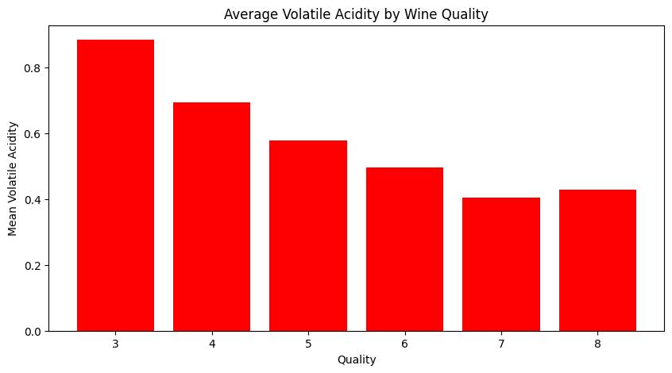

```python
fig = plt.figure(figsize=(10, 5))

# Grouping data by 'quality' and calculating the mean of 'volatile acidity' for each group
quality_mean_volatile_acidity = wine.groupby("quality")["volatile acidity"].mean()

# Extracting quality values and their corresponding mean volatile acidity values
quality_values = quality_mean_volatile_acidity.index
mean_volatile_acidity = quality_mean_volatile_acidity.values

# Creating a bar plot
plt.bar(quality_values, mean_volatile_acidity, color="red")

# Adding title and labels
plt.title("Average Volatile Acidity by Wine Quality")
plt.xlabel("Quality")
plt.ylabel("Mean Volatile Acidity")

# Show the plot
plt.show()
```

Much like before, this plot aims to display the relationship between the mean 'volatile acidity' attribute and wine quality for each quality grouping. We can tell from the graph that there appears to be a clear downward trend in volatile acidity as the graph increases in quality.

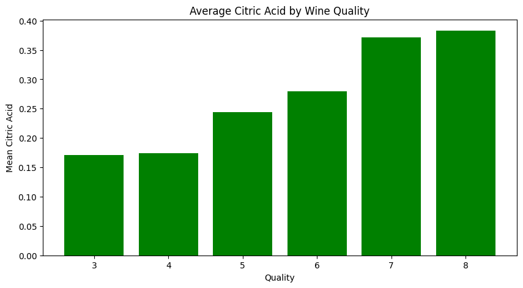

```python
# Grouping data by 'quality' and calculating the mean of 'citric acid' for each group
quality_mean_citric_acid = wine.groupby("quality")["citric acid"].mean()

# Extracting quality values and their corresponding mean citric acid values
quality_values = quality_mean_citric_acid.index
mean_citric_acid = quality_mean_citric_acid.values

# Creating a bar plot
plt.figure(figsize=(10, 5))
plt.bar(quality_values, mean_citric_acid, color="green")

# Adding title and labels
plt.title("Average Citric Acid by Wine Quality")
plt.xlabel("Quality")
plt.ylabel("Mean Citric Acid")

# Show the plot
plt.show()
```

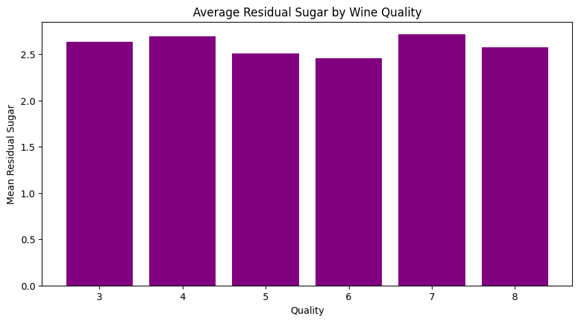

```python
# Grouping data by 'quality' and calculating the mean of 'residual sugar' for each group
quality_mean_residual_sugar = wine.groupby("quality")["residual sugar"].mean()

# Extracting quality values and their corresponding mean residual sugar values
quality_values = quality_mean_residual_sugar.index
mean_residual_sugar = quality_mean_residual_sugar.values

# Creating a bar plot
plt.figure(figsize=(10, 5))
plt.bar(quality_values, mean_residual_sugar, color="purple")

# Adding title and labels
plt.title("Average Residual Sugar by Wine Quality")
plt.xlabel("Quality")
plt.ylabel("Mean Residual Sugar")

# Show the plot
plt.show()
```

This plot aims to display the relationship between the mean 'residual sugar' attribute and wine quality for each quality grouping. We can tell from the graph that there does not appear to be a clear trend in the relationship of residual sugar to wine quality.

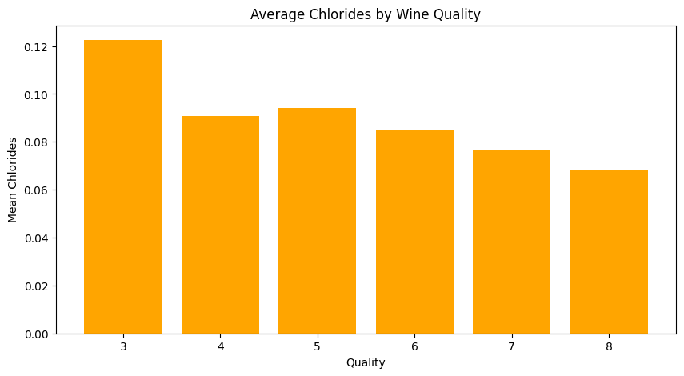

```python
# Grouping data by 'quality' and calculating the mean of 'chlorides' for each group
quality_mean_chlorides = wine.groupby("quality")["chlorides"].mean()

# Extracting quality values and their corresponding mean chlorides values
quality_values = quality_mean_chlorides.index
mean_chlorides = quality_mean_chlorides.values

# Creating a bar plot
plt.figure(figsize=(10, 5))
plt.bar(quality_values, mean_chlorides, color="orange")

# Adding title and labels
plt.title("Average Chlorides by Wine Quality")
plt.xlabel("Quality")
plt.ylabel("Mean Chlorides")

# Show the plot
plt.show()
```

This plot aims to display the relationship between the mean 'chlorides' attribute and wine quality for each quality grouping. We can tell from the graph that there appears to be a downward trend between the chloride composition and percieved wine quality.

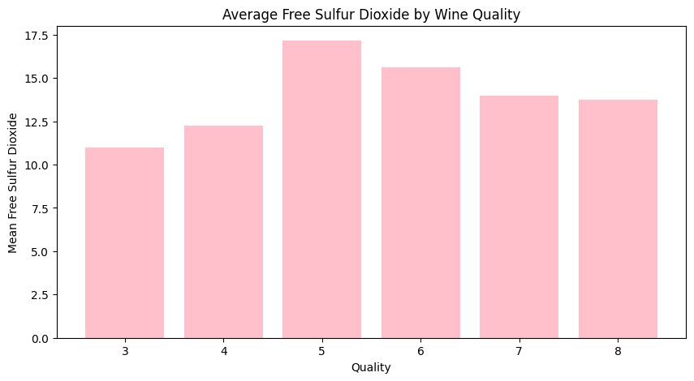

```python
# Grouping data by 'quality' and calculating the mean of 'free sulfur dioxide' for each group
quality_mean_free_sulfur_dioxide = wine.groupby("quality")["free sulfur dioxide"].mean()

# Extracting quality values and their corresponding mean free sulfur dioxide values
quality_values = quality_mean_free_sulfur_dioxide.index
mean_free_sulfur_dioxide = quality_mean_free_sulfur_dioxide.values

# Creating a bar plot
plt.figure(figsize=(10, 5))
plt.bar(quality_values, mean_free_sulfur_dioxide, color="pink")

# Adding title and labels
plt.title("Average Free Sulfur Dioxide by Wine Quality")
plt.xlabel("Quality")
plt.ylabel("Mean Free Sulfur Dioxide")

# Show the plot
plt.show()
```

This plot aims to display the relationship between the mean 'free sulfur dioxide' attribute and wine quality for each quality grouping. We can tell from the graph that there does not appear to be a clear trend in the relationship of free sulfur dioxide to wine quality.

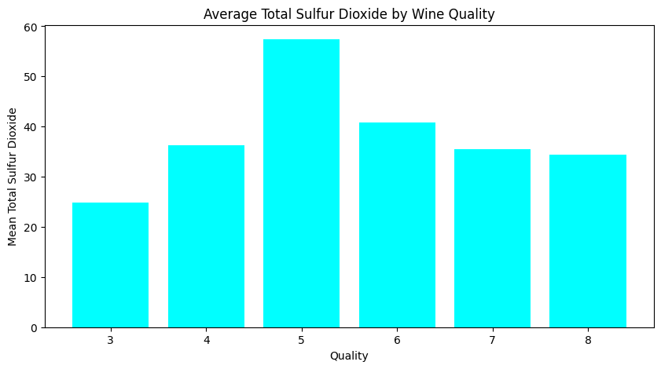

```python
# Grouping data by 'quality' and calculating the mean of 'total sulfur dioxide' for each group
quality_mean_total_sulfur_dioxide = wine.groupby("quality")[
    "total sulfur dioxide"
].mean()

# Extracting quality values and their corresponding mean total sulfur dioxide values
quality_values = quality_mean_total_sulfur_dioxide.index
mean_total_sulfur_dioxide = quality_mean_total_sulfur_dioxide.values

# Creating a bar plot
plt.figure(figsize=(10, 5))
plt.bar(quality_values, mean_total_sulfur_dioxide, color="cyan")

# Adding title and labels
plt.title("Average Total Sulfur Dioxide by Wine Quality")
plt.xlabel("Quality")
plt.ylabel("Mean Total Sulfur Dioxide")

# Show the plot
plt.show()
```

This plot aims to display the relationship between the mean 'total sulfur dioxide' attribute and wine quality for each quality grouping. We can tell from this graph and the previous that there does not appear to be a clear trend in the relationship of sulfur dioxide to wine quality.

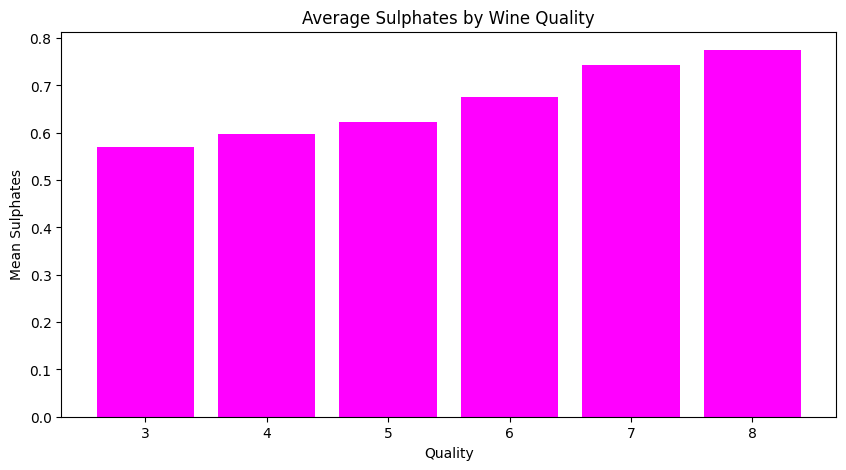

```python
# Grouping data by 'quality' and calculating the mean of 'sulphates' for each group
quality_mean_sulphates = wine.groupby("quality")["sulphates"].mean()

# Extracting quality values and their corresponding mean sulphates values
quality_values = quality_mean_sulphates.index
mean_sulphates = quality_mean_sulphates.values

# Creating a bar plot
plt.figure(figsize=(10, 5))
plt.bar(quality_values, mean_sulphates, color="magenta")

# Adding title and labels
plt.title("Average Sulphates by Wine Quality")
plt.xlabel("Quality")
plt.ylabel("Mean Sulphates")

# Show the plot
plt.show()
```

This plot aims to display the relationship between the mean 'sulphate' composition attribute and wine quality for each quality grouping. We can tell from the graph that there appears to be a clear upward trend in the relationship of sulphate to wine quality.

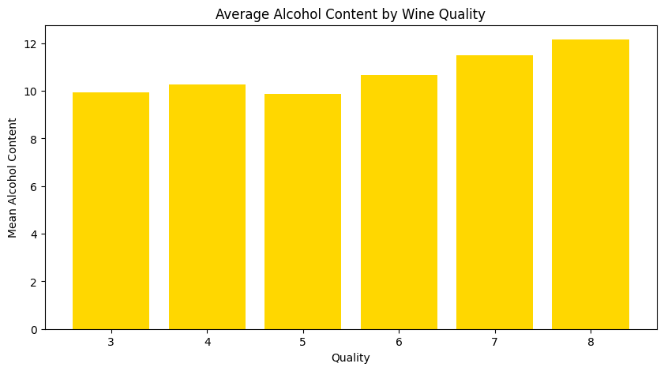

```python
quality_mean_alcohol = wine.groupby("quality")["alcohol"].mean()

# Extracting quality values and their corresponding mean alcohol values
quality_values = quality_mean_alcohol.index
mean_alcohol = quality_mean_alcohol.values

# Creating a bar plot
plt.figure(figsize=(10, 5))
plt.bar(quality_values, mean_alcohol, color="gold")

# Adding title and labels
plt.title("Average Alcohol Content by Wine Quality")
plt.xlabel("Quality")
plt.ylabel("Mean Alcohol Content")

# Show the plot
plt.show()
```

This plot aims to display the relationship between the mean 'alcohol' content attribute and wine quality for each quality grouping. We can tell from the graph that there appears to be a slight upward trend in the relationship of alcohol content to wine quality.

## Part 3: Model: Analysis, Hypothesis Testing, Machine Learning

Now we are ready to begin developing our ML model! We will begin with some simple preprocessing:

```python
y = wine["quality"]
x = wine.drop(["quality"], axis=1)

x_train, x_test, y_train, y_test = train_test_split(
    x, y, test_size=0.3, random_state=42
)

# Center the data
sc = StandardScaler()
x_train = sc.fit_transform(x_train)
x_test = sc.fit_transform(x_test)

# training and testing data is now ready for use in our ML models
x_train.shape, x_test.shape, y_train.shape, y_test.shape
```

```
((951, 11), (408, 11), (951,), (408,))
```

The target variable, "quality," is extracted from the dataset and stored in the variable "y," while the input features are stored in the variable "x" after removing the "quality" column using the "drop" function along the specified axis.

Next, the dataset is split into training and testing sets using the "train_test_split" function from a machine learning library (possibly scikit-learn). The dataset is divided into two portions: a training set used for training the machine learning models and a testing set for evaluating their performance. The split is defined such that 30% of the data is allocated to the testing set, and a random seed of 42 is used to ensure reproducibility.

Subsequently, the data is being centered or standardized using the "StandardScaler" from the same library. This step is crucial for ensuring that the features have similar scales, which is particularly important for algorithms sensitive to feature scales, such as support vector machines. The "fit_transform" function is applied to both the training and testing data using the scaler, resulting in transformed data that has a mean of zero and a standard deviation of one.

### Logistic Regression

```python
lr = LogisticRegression(max_iter=10000)

lr.fit(x_train, y_train)
lr.score(x_train, y_train)
```

```
0.5888538380651945
```

This score (also called the training accuracy) represents how well the logistic regression model fits the training data it was trained on. In this case, the model correctly predicted the target quality approximately 58.89% of the time on the training data. It means that the model learned to capture some patterns and relationships present in the training data.

```python
lr.score(x_test, y_test)
```

```
0.6053921568627451
```

This score (also called the test accuracy) indicates how well the logistic regression model performs on new, unseen data that it wasn't exposed to during training. In this case, the model correctly predicted the target variable about 60.54% of the time on the test data. This suggests that the model's ability to generalize to new data is slightly better than its performance on the training data.

The test score is higher than the training score which is typically a good sign. However, these scores are relatively close, and the overall accuracy of the logistic model doesn't seem to be very high. Let's take a look at our confusion matrix for this model.

```
<sklearn.metrics._plot.confusion_matrix.ConfusionMatrixDisplay at 0x7f3c01f79010>
```

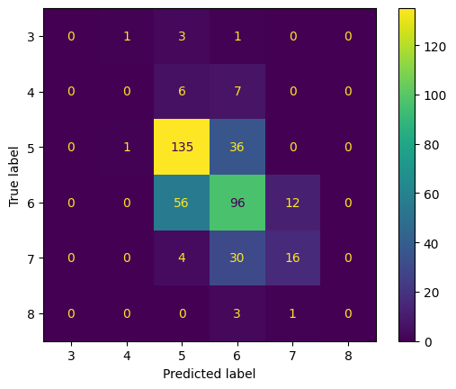

```python
y_pred = lr.predict(x_test)
cmd = ConfusionMatrixDisplay(
    confusion_matrix=confusion_matrix(y_test, y_pred, labels=lr.classes_),
    display_labels=lr.classes_,
)
cmd.plot()
```

The confusion matrix suggests that our logistic model works best for predicting qualities in the 5-6 range. This is reasonable because most of the training data for this model has been on wines in this quality range. The model is somewhat prone to confusion when identifying between the two quality levels, and can predict quality 7 wines with a degree of accuracy as well. Let's see if we can improve on this model by using a different algorithm.

### KNN Classification

```python
from sklearn.neighbors import KNeighborsClassifier

knn = KNeighborsClassifier(n_neighbors=6, metric="euclidean")
knn.fit(x_train,y_train)
knn.score(x_train,y_train)
```

```
0.6813880126182965
```

```python
knn.score(x_test,y_test)
```

```
0.5784313725490197
```

This score shows our model correctly generalizes to new data roughly 57.84% of the time. This means that is worse at predicting new data than the training data and suggests KNN may not be the most appropriate algorithm to use for predicting wine quality.

```
<sklearn.metrics._plot.confusion_matrix.ConfusionMatrixDisplay at 0x7f3c01d02cd0>
```

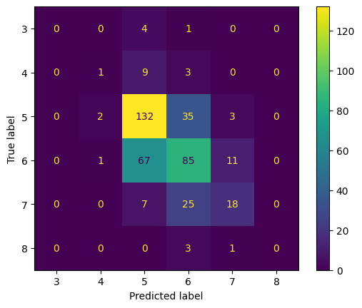

```python
y_pred=knn.predict(x_test)
cmd=ConfusionMatrixDisplay(confusion_matrix=confusion_matrix(y_test,y_pred,labels=knn.classes_),display_labels=knn.classes_)
cmd.plot()
```

This confusion matrix corroborates the KNN model as being a slightly worse predictor of most wine qualities than the logistic model. Like before, it is most accurate in the 5-6 range, appearing to accurately predict wines in the quality 6 range slightly less often.

### SVC Classification

Support Vector Machines (SVM) is a machine learning algorithm used for both classification and regression tasks. It works by finding a hyperplane that best separates different classes or predicts values in the case of regression. This hyperplane maximizes the margin, which is the distance between the hyperplane and the closest data points from each class. The algorithm aims to find the optimal hyperplane by identifying support vectors, which are data points lying closest to the decision boundary. By transforming the data into a higher-dimensional space using a kernel function, SVM can handle non-linear relationships between features. The goal of SVM is to achieve a balance between maximizing the margin and minimizing classification errors, leading to robust and generalized models. Let's see if it can give us a more accurate model for predicting quality than KNN or the logistic regression.

```python
from sklearn.svm import SVC

svc=SVC()

svc.fit(x_train,y_train)
svc.score(x_train,y_train)
```

```
0.6519453207150369
```

```python
svc.score(x_test,y_test)
```

```
0.6225490196078431
```

Our testing score appears a bit higher now at 62.25% accuracy for predicting new data. This is promising as it is our highest testing score yet.

```
<sklearn.metrics._plot.confusion_matrix.ConfusionMatrixDisplay at 0x7f3c022f6c50>
```

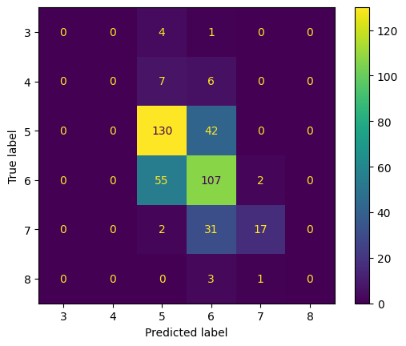

```python
y_pred=svc.predict(x_test)
cmd=ConfusionMatrixDisplay(confusion_matrix=confusion_matrix(y_test,y_pred,labels=svc.classes_),display_labels=svc.classes_)

cmd.plot()
```

The SVC algorithm is our most accurate model so far and shows stronger accuracy particularly in the higher quality ranges such as 6-7. Also like previous quality graphs, wines truly in the lower quality ranges are often predicted at higher quality ranges, though this pattern does not appear to extend into the higher ranges for this algorithm.

Let's try to improve on this model using Grid Search CV, a parameter tuning technique. It involves systematically searching through a specified range of hyperparameter values for a given model and evaluating the model's performance using cross-validation. The idea is to exhaustively explore various combinations of hyperparameters to find the set that yields the best model performance. Grid Search CV automates this process by creating a grid of hyperparameter values and systematically trying all possible combinations, assessing each combination's performance through cross-validation. The combination that achieves the highest cross-validated performance score will then be selected as the optimal set of hyperparameters for the model.

```python
from sklearn.model_selection import GridSearchCV

param = {
    'C': [0.1,0.8,0.9,1,1.1,1.2,1.3,1.4],
    'kernel':['linear', 'rbf'],
    'gamma' :[0.1,0.8,0.9,1,1.1,1.2,1.3,1.4]
}
grid_svc = GridSearchCV(svc, param_grid=param, scoring='accuracy', cv=10)
grid_svc.fit(x_train, y_train)
grid_svc.best_params_
```

```
{'C': 1.3, 'gamma': 0.1, 'kernel': 'rbf'}
```

```
<sklearn.metrics._plot.confusion_matrix.ConfusionMatrixDisplay at 0x7f3c02513d90>
```

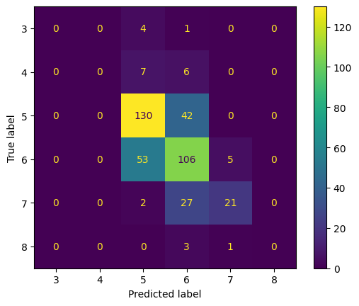

```python
# Now we can run our SVC model again with the optimal parameters
svc2 = SVC(C = 1.3, gamma =  0.1, kernel= 'rbf')
svc2.fit(x_train, y_train)
y_pred = svc2.predict(x_test)
cmd=ConfusionMatrixDisplay(confusion_matrix=confusion_matrix(y_test,y_pred,labels=svc2.classes_),display_labels=svc2.classes_)
cmd.plot()
```

```python
from sklearn.metrics import classification_report


print(classification_report(y_test, y_pred))
```

```
              precision    recall  f1-score   support

           3       0.00      0.00      0.00         5
           4       0.00      0.00      0.00        13
           5       0.66      0.76      0.71       172
           6       0.57      0.65      0.61       164
           7       0.78      0.42      0.55        50
           8       0.00      0.00      0.00         4

    accuracy                           0.63       408
   macro avg       0.34      0.30      0.31       408
weighted avg       0.61      0.63      0.61       408
```

Our optimized SVC model appears to be slightly more accurate in the higher quality ranges such as 7, which is significant since there was a general lack of training data in those echelons. We will be using this to develop further insights regarding the most strongly correlated attributes with perceived wine quality.

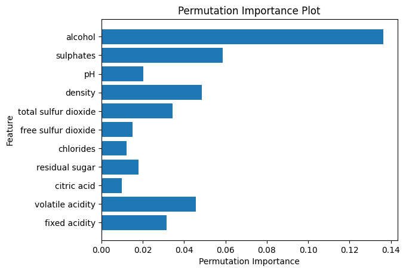

```python
from sklearn.inspection import permutation_importance

result = permutation_importance(svc2, x_test, y_test, n_repeats=30, random_state=0)
feature_importance = result.importances_mean
feature_names = x.columns

plt.barh(feature_names, feature_importance)
plt.xlabel('Permutation Importance')
plt.ylabel('Feature')
plt.title('Permutation Importance Plot')
plt.show()
```

### Interpretations and Conclusions

Our adjusted SVC model is the most accurate we have determined. It seems to be most accurate at predicting mid to high quality wines. On the contrary, recall is highest in the mid-ranges and decreases for higher quality wines.

As you can see from the plot, by far the most statistically significant attribute in determining wine quality is the alcoholic content. This is followed by sulphates, density, and volatile acidity respectively.

This data provides insight as to what factors influence consumers' quality rating of a given wine. This can influence purchasing and other buisness decisions on the part of wineries and larger producers in terms of grape variety, growing conditions, the distillation process, or other changes that can adjust these attributes as needed.

The following is a list of high-quality resources on technologies and ideas that were employed in the course of this project. Click a given link to learn more about the topic.

- [Tidy Data](https://vita.had.co.nz/papers/tidy-data.pdf) - paper by Hadley Wickham that introduces the principles of tidy data, an important concept in data curation and management.
- [Exploratory Data Analysis in Python](https://towardsdatascience.com/exploratory-data-analysis-in-python-c9a77dfa39ce) - A detailed guide on EDA techniques using Python libraries like Pandas, Matplotlib, and Seaborn.
- [The Art of Visualization](https://towardsdatascience.com/the-art-of-data-visualization-2167ad6202b5) - An in-depth guide to creating effective data visualizations that convey insights clearly.
- [A Beginner Guide to Hypothesis Testing](https://towardsdatascience.com/a-gentle-introduction-to-hypothesis-testing-9b279d58fda2) - A beginner-friendly guide to understanding and performing hypothesis tests.
- [Introduction to Machine Learning Algorithms](https://towardsdatascience.com/introduction-to-machine-learning-algorithms-89a1f1e3af7e) - An overview of popular machine learning algorithms and their applications.